# Predicting Heart Disease Severity

Author

Zaynab El Hakour

Published

May 11, 2026

## Introduction

Heart disease remains the leading cause of death in the United States, responsible for roughly one in five deaths each year. Early and accurate diagnosis is critical. A patient with mild coronary narrowing may need lifestyle changes and monitoring, while someone with severe blockages may require immediate intervention.

In this analysis, we use clinical data collected from patients across four medical centers to build a model that predicts the **severity** of heart disease on a five-point scale (0 = no disease, 4 = most severe).

The dataset comes from the [UCI Heart Disease dataset](https://www.kaggle.com/datasets/redwankarimsony/heart-disease-uci) and contains 920 patient records with 13 clinical features including age, resting blood pressure, cholesterol, and results from exercise stress tests.

```python
import pandas as pd
import numpy as np
import matplotlib.pyplot as plt
import matplotlib.ticker as mticker
import seaborn as sns

from sklearn.model_selection import train_test_split, GridSearchCV, StratifiedKFold
from sklearn.preprocessing import StandardScaler, OneHotEncoder
from sklearn.impute import SimpleImputer
from sklearn.compose import ColumnTransformer
from sklearn.pipeline import Pipeline
from sklearn.linear_model import LogisticRegression
from sklearn.ensemble import RandomForestClassifier
from sklearn.metrics import (classification_report, confusion_matrix,
                             ConfusionMatrixDisplay, balanced_accuracy_score)
#Loading the data
df_raw = pd.read_csv("data/heart_disease_uci.csv")
print(f"Dataset shape: {df_raw.shape}")
df_raw.head()
```

```
Dataset shape: (920, 16)
```

|  | id | age | sex | dataset | cp | trestbps | chol | fbs | restecg | thalch | exang | oldpeak | slope | ca | thal | num |
| --- | --- | --- | --- | --- | --- | --- | --- | --- | --- | --- | --- | --- | --- | --- | --- | --- |
| 0 | 1 | 63 | Male | Cleveland | typical angina | 145.0 | 233.0 | True | lv hypertrophy | 150.0 | False | 2.3 | downsloping | 0.0 | fixed defect | 0 |
| 1 | 2 | 67 | Male | Cleveland | asymptomatic | 160.0 | 286.0 | False | lv hypertrophy | 108.0 | True | 1.5 | flat | 3.0 | normal | 2 |
| 2 | 3 | 67 | Male | Cleveland | asymptomatic | 120.0 | 229.0 | False | lv hypertrophy | 129.0 | True | 2.6 | flat | 2.0 | reversable defect | 1 |
| 3 | 4 | 37 | Male | Cleveland | non-anginal | 130.0 | 250.0 | False | normal | 187.0 | False | 3.5 | downsloping | 0.0 | normal | 0 |
| 4 | 5 | 41 | Female | Cleveland | atypical angina | 130.0 | 204.0 | False | lv hypertrophy | 172.0 | False | 1.4 | upsloping | 0.0 | normal | 0 |

## Exploratory Data Analysis

### Class Distribution

Before diving into features, it helps to understand the shape of what we’re trying to predict. The severity scores are notably imbalanced: nearly half of patients show no disease, while the most severe class (4) accounts for only 3% of the data. This imbalance will inform our modeling choices later.

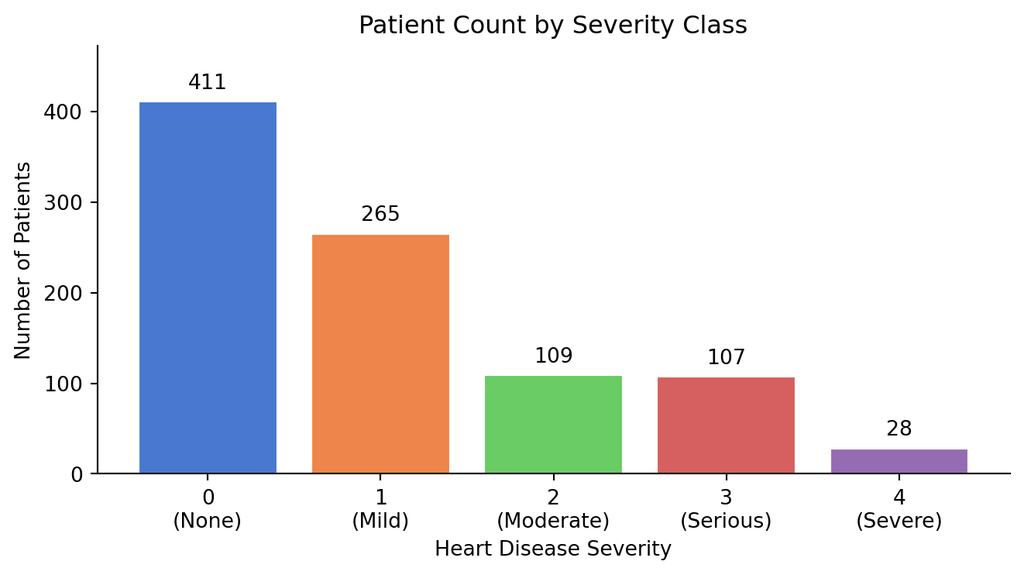

```python
fig, ax = plt.subplots(figsize=(7, 4))
labels = ["0\n(None)", "1\n(Mild)", "2\n(Moderate)", "3\n(Serious)", "4\n(Severe)"]
counts = df_raw["num"].value_counts().sort_index()
bars = ax.bar(labels, counts.values, color=sns.color_palette("muted", 5), edgecolor="white", linewidth=0.8)
ax.bar_label(bars, fmt="%d", padding=4, fontsize=10)
ax.set_xlabel("Heart Disease Severity")
ax.set_ylabel("Number of Patients")
ax.set_title("Patient Count by Severity Class")
ax.set_ylim(0, counts.max() * 1.15)
sns.despine()
plt.tight_layout()
plt.show()
```

### Feature Overview & Missingness

Before examining missingness, we drop two columns that carry no clinical information: the patient ID, which is an arbitrary identifier, and the medical center label, which reflects where data was collected rather than anything about the patient’s health.

```python
df_raw = df_raw.drop(columns=["id", "dataset"])
df_raw.head()
```

|  | age | sex | cp | trestbps | chol | fbs | restecg | thalch | exang | oldpeak | slope | ca | thal | num |
| --- | --- | --- | --- | --- | --- | --- | --- | --- | --- | --- | --- | --- | --- | --- |
| 0 | 63 | Male | typical angina | 145.0 | 233.0 | True | lv hypertrophy | 150.0 | False | 2.3 | downsloping | 0.0 | fixed defect | 0 |
| 1 | 67 | Male | asymptomatic | 160.0 | 286.0 | False | lv hypertrophy | 108.0 | True | 1.5 | flat | 3.0 | normal | 2 |
| 2 | 67 | Male | asymptomatic | 120.0 | 229.0 | False | lv hypertrophy | 129.0 | True | 2.6 | flat | 2.0 | reversable defect | 1 |
| 3 | 37 | Male | non-anginal | 130.0 | 250.0 | False | normal | 187.0 | False | 3.5 | downsloping | 0.0 | normal | 0 |
| 4 | 41 | Female | atypical angina | 130.0 | 204.0 | False | lv hypertrophy | 172.0 | False | 1.4 | upsloping | 0.0 | normal | 0 |

The following table below summarizes the features with missing data, ordered from most to least incomplete:

```python
name_map = {
    "sex":      "Sex (sex)",
    "cp":       "Chest Pain Type (cp)",
    "trestbps": "Resting Blood Pressure in mmHg (trestbps)",
    "chol":     "Serum Cholesterol in mg/dL (chol)",
    "fbs":      "Fasting Blood Sugar > 120 mg/dL (fbs)",
    "restecg":  "Resting ECG Results (restecg)",
    "thalch":   "Maximum Heart Rate Achieved (thalch)",
    "exang":    "Exercise-Induced Angina (exang)",
    "oldpeak":  "ST Depression Induced by Exercise (oldpeak)",
    "slope":    "Slope of Peak Exercise ST Segment (slope)",
    "ca":       "Number of Major Vessels Colored by Fluoroscopy (ca)",
    "thal":     "Thalassemia Stress Test Result (thal)",
    "num":      "Heart Disease Severity Score (num)",
}

# Compute missingness summary for all columns
miss = df_raw.isnull().sum()
miss_pct = (miss / len(df_raw) * 100).round(1)
miss_df = pd.DataFrame({"# Missing": miss, "% Missing": miss_pct})
miss_df = miss_df.sort_values("# Missing", ascending=False)
miss_df.index = [name_map.get(i, i) for i in miss_df.index]
miss_df
```

|  | # Missing | % Missing |
| --- | --- | --- |
| Number of Major Vessels Colored by Fluoroscopy (ca) | 611 | 66.4 |
| Thalassemia Stress Test Result (thal) | 486 | 52.8 |
| Slope of Peak Exercise ST Segment (slope) | 309 | 33.6 |
| Fasting Blood Sugar > 120 mg/dL (fbs) | 90 | 9.8 |
| ST Depression Induced by Exercise (oldpeak) | 62 | 6.7 |
| Resting Blood Pressure in mmHg (trestbps) | 59 | 6.4 |
| Maximum Heart Rate Achieved (thalch) | 55 | 6.0 |
| Exercise-Induced Angina (exang) | 55 | 6.0 |
| Serum Cholesterol in mg/dL (chol) | 30 | 3.3 |
| Resting ECG Results (restecg) | 2 | 0.2 |
| Chest Pain Type (cp) | 0 | 0.0 |
| Sex (sex) | 0 | 0.0 |
| age | 0 | 0.0 |
| Heart Disease Severity Score (num) | 0 | 0.0 |

The dataset includes a mix of demographic information, resting measurements, and exercise test results. Three features, `slope` (the slope of the ST segment during peak exercise ), `ca` (the number of major coronary vessels narrowed as seen by fluoroscopy), and `thal` ( reversible cardiac defects) are missing for more than a third of patients (and `ca` and `thal` for over half). Rather than impute such large portions of the data, we drop these columns and work with the remaining ten clinical features, which are complete or nearly so.

Resting blood pressure `trestbps` and cholesterol `chol` cannot be zero in a living patient. A blood pressure of zero means no circulation, and a cholesterol of zero is biologically impossible. When these appear in the data they are almost certainly cases where a value was left blank and recorded as zero rather than left null.

### Exploratory Analysis of Clinical Features by Heart Disease Severity

A good first check is whether our features actually separate the severity classes. Several show clear trends.

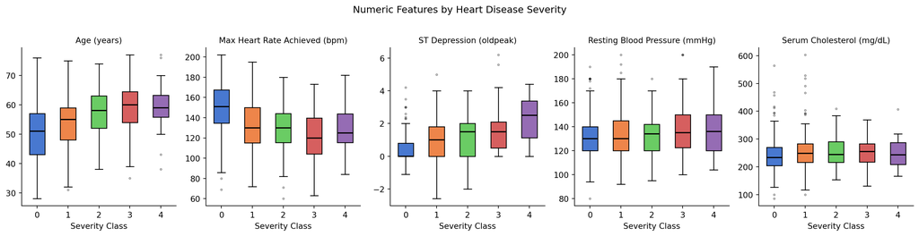

```python
# Prepare a lightly cleaned version just for EDA plots
df_eda = df_raw.copy()
df_eda["trestbps"] = df_eda["trestbps"].replace(0, np.nan)
df_eda["chol"] = df_eda["chol"].replace(0, np.nan)

numeric_features = {
    "age": "Age (years)",
    "thalch": "Max Heart Rate Achieved (bpm)",
    "oldpeak": "ST Depression (oldpeak)",
    "trestbps": "Resting Blood Pressure (mmHg)",
    "chol": "Serum Cholesterol (mg/dL)",
}

fig, axes = plt.subplots(1, 5, figsize=(16, 4))
severity_labels = ["0", "1", "2", "3", "4"]

for ax, (col, label) in zip(axes, numeric_features.items()):
    data_by_class = [df_eda[df_eda["num"] == c][col].dropna().values for c in range(5)]
    bp = ax.boxplot(data_by_class, patch_artist=True, medianprops=dict(color="black", linewidth=1.5),
                    flierprops=dict(marker="o", markersize=2, alpha=0.4))
    colors = sns.color_palette("muted", 5)
    for patch, color in zip(bp["boxes"], colors):
        patch.set_facecolor(color)
    ax.set_xticklabels(severity_labels)
    ax.set_xlabel("Severity Class")
    ax.set_title(label, fontsize=10)
sns.despine()
plt.suptitle("Numeric Features by Heart Disease Severity", y=1.02, fontsize=12)
plt.tight_layout()
plt.show()
```

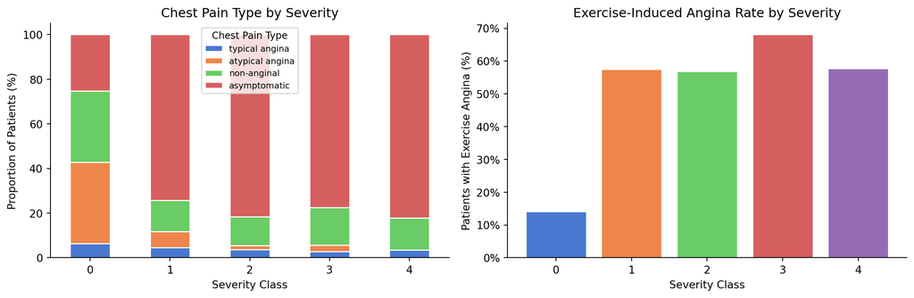

```python
# Categorical feature: chest pain type & sex
fig, axes = plt.subplots(1, 2, figsize=(12, 4))

# Chest pain type proportions by severity
cp_order = ["typical angina", "atypical angina", "non-anginal", "asymptomatic"]
cp_counts = (df_eda.groupby(["num", "cp"])
               .size()
               .unstack(fill_value=0)
               .reindex(columns=cp_order, fill_value=0))
cp_pct = cp_counts.div(cp_counts.sum(axis=1), axis=0) * 100
cp_pct.plot(kind="bar", stacked=True, ax=axes[0],
            color=sns.color_palette("muted", 4), edgecolor="white")
axes[0].set_xlabel("Severity Class")
axes[0].set_ylabel("Proportion of Patients (%)")
axes[0].set_title("Chest Pain Type by Severity")
axes[0].set_xticklabels(["0","1","2","3","4"], rotation=0)
axes[0].legend(title="Chest Pain Type", fontsize=8, title_fontsize=9)

# Exercise-induced angina rate by severity
exang_rate = df_eda.groupby("num")["exang"].mean() * 100
axes[1].bar(range(5), exang_rate.values, color=sns.color_palette("muted", 5), edgecolor="white")
axes[1].set_xticks(range(5))
axes[1].set_xticklabels(["0","1","2","3","4"])
axes[1].set_xlabel("Severity Class")
axes[1].set_ylabel("Patients with Exercise Angina (%)")
axes[1].set_title("Exercise-Induced Angina Rate by Severity")
axes[1].yaxis.set_major_formatter(mticker.FormatStrFormatter("%.0f%%"))

sns.despine()
plt.tight_layout()
plt.show()
```

## Data Preprocessing

With the exploratory picture in hand, we prepare the data for modeling. After dropping the three high-missingness columns and fixing implausible zero values, we encode boolean features numerically. Imputation, scaling, and one-hot encoding of categorical variables are handled inside the model pipelines.

```python
# Dropping high-missingness columns
df = df_raw.drop(columns=["slope", "ca", "thal"]).copy()

# Treating physiologically impossible zeros as missing
df["trestbps"] = df["trestbps"].replace(0, np.nan)
df["chol"]     = df["chol"].replace(0, np.nan)

# Mapping boolean columns to 0/1, preserving NaN
df["exang"] = df["exang"].map({True: 1, False: 0})
df["fbs"]   = df["fbs"].map({True: 1, False: 0})
df["sex"]   = (df["sex"] == "Male").astype(int)

# Filling the small number of missing categorical values with the mode
# so the one-hot encoder does not create a spurious NaN category
df["restecg"] = df["restecg"].fillna(df["restecg"].mode()[0])
df["cp"]      = df["cp"].fillna(df["cp"].mode()[0])

# Defining feature groups for the ColumnTransformer
numeric_cols     = ["age", "trestbps", "chol", "thalch", "oldpeak"]
binary_cols      = ["sex", "fbs", "exang"]
categorical_cols = ["cp", "restecg"]

X = df.drop(columns=["num"])
y = df["num"]

# Splitting the data
X_train, X_test, y_train, y_test = train_test_split(
    X, y, test_size=0.2, random_state=42, stratify=y
)

print(f"Training set: {X_train.shape[0]} patients")
print(f"Test set:     {X_test.shape[0]} patients")
```

```
Training set: 736 patients
Test set:     184 patients
```

We use a `ColumnTransformer` to apply appropriate preprocessing to each feature group: median imputation for numeric and binary columns, and one-hot encoding for chest pain type and resting ECG results.

```python
# One-hot encoding is necessary because both logistic regression and random forest expect numeric inputs. Assigning arbitrary integers to categories like chest pain type would allow  the model to incorrectly learn.

preprocessor = ColumnTransformer(transformers=[
    ("num", SimpleImputer(strategy="median"), numeric_cols + binary_cols),
    ("cat", OneHotEncoder(drop="first", handle_unknown="ignore"), categorical_cols),
])
```

## Modeling

Logistic regression is used for our interpretable baseline. We tune the regularization strength via grid search controlling how strongly the model penalizes large coefficients.

```python
lr_pipeline = Pipeline([
    ("preprocessor", preprocessor),
    ("scaler",        StandardScaler(with_mean=False)),
    ("model",         LogisticRegression(
                          solver="lbfgs",
                          class_weight="balanced",
                          max_iter=5000,
                          random_state=42))
])

lr_params = {"model__C": [0.01, 0.1, 0.5, 1.0, 5.0, 10.0]}
cv = StratifiedKFold(n_splits=5, shuffle=True, random_state=42)

lr_search = GridSearchCV(
    lr_pipeline, lr_params,
    cv=cv, scoring="balanced_accuracy", n_jobs=-1
)
lr_search.fit(X_train, y_train)

y_pred_lr  = lr_search.predict(X_test)
bal_acc_lr = balanced_accuracy_score(y_test, y_pred_lr)

print(f"Best C:                {lr_search.best_params_['model__C']}")
```

```
Best C:                0.1
```

The model performed best when it was kept relatively simple.

```python
print(f"Best CV Bal. Accuracy: {lr_search.best_score_:.3f}")
```

```
Best CV Bal. Accuracy: 0.382
```

During training/testing splits, the model correctly identified classes about 38.2% of the time on average, while treating all classes equally.

```python
print(f"Test Bal. Accuracy:    {bal_acc_lr:.3f}")
```

```
Test Bal. Accuracy:    0.335
```

On completely new unseen data, the model got about 33.5% balanced accuracy. This is lower than the cross-validation score (38.2%), which means the model does not generalize very strongly to new data.

```python
print(classification_report(y_test, y_pred_lr,
      target_names=["None","Mild","Moderate","Serious","Severe"]))
```

```
              precision    recall  f1-score   support

        None       0.85      0.71      0.77        82
        Mild       0.42      0.28      0.34        53
    Moderate       0.10      0.09      0.10        22
     Serious       0.06      0.10      0.08        21
      Severe       0.11      0.50      0.18         6

    accuracy                           0.43       184
   macro avg       0.31      0.34      0.29       184
weighted avg       0.52      0.43      0.47       184
```

#### Interpretations

- The model predicted correctly **43%** of the time overall.
- The model is pretty good at identifying **NONE**.
- The model struggles with **MILD**.
- The model barely recognizes the **MODERATE** and **SERIOUS** categories correctly.
- The model catches half of **SEVERE** cases.
- For `macro avg f1 = 0.29`, the model is not balanced across categories.
- For `weighted avg f1 = 0.47`since “None” performs well and appears often, this score looks better.
- Overall, my Logistic Regression model works reasonably for the majority class (“None”), but struggles heavily on minority classes.

### Random Forest

Next, we fit a random forest, which can capture non-linear relationships and feature interactions that logistic regression cannot. We tune the number of trees, maximum tree depth, and minimum samples required to split a node.

```python
rf_pipeline = Pipeline([
    ("preprocessor", preprocessor),
    ("model",         RandomForestClassifier(
                          class_weight="balanced",
                          random_state=42,
                          n_jobs=-1))
])

rf_params = {
    "model__n_estimators":      [100, 300],
    "model__max_depth":         [None, 10, 20],
    "model__min_samples_split": [2, 5],
}

rf_search = GridSearchCV(
    rf_pipeline, rf_params,
    cv=cv, scoring="balanced_accuracy", n_jobs=-1
)
rf_search.fit(X_train, y_train)

y_pred_rf  = rf_search.predict(X_test)
bal_acc_rf = balanced_accuracy_score(y_test, y_pred_rf)

print(f"Best params:           {rf_search.best_params_}")
```

```
Best params:           {'model__max_depth': 10, 'model__min_samples_split': 5, 'model__n_estimators': 100}
```

**{max_depth 10, min_samples_split 5, n_estimators 100}:** The grid search found that shallow trees (maximum depth of 10) with a minimum of 5 samples required to make a split generalize better than deeper, more complex trees.

```python
print(f"Best CV Bal. Accuracy: {rf_search.best_score_:.3f}")
```

```
Best CV Bal. Accuracy: 0.362
```

**Best CV Balanced Accuracy: 0.362 vs Test Balanced Accuracy: 0.344** The gap here is smaller than logistic regression’s gap (0.382 → 0.335). Both models are in the same ballpark overall.

```python
print(f"Test Bal. Accuracy:    {bal_acc_rf:.3f}")
```

```
Test Bal. Accuracy:    0.344
```

```python
print(classification_report(y_test, y_pred_rf,
      target_names=["None","Mild","Moderate","Serious","Severe"]))
```

```
              precision    recall  f1-score   support

        None       0.81      0.76      0.78        82
        Mild       0.41      0.38      0.39        53
    Moderate       0.12      0.14      0.13        22
     Serious       0.19      0.29      0.23        21
      Severe       0.50      0.17      0.25         6

    accuracy                           0.50       184
   macro avg       0.41      0.34      0.36       184
weighted avg       0.53      0.50      0.51       184
```

### Gradient Boosting

Gradient boosting builds trees sequentially, each one correcting the errors of the last. `HistGradientBoostingClassifier` handles missing values natively, so we remove the imputer from this pipeline.

```python
from sklearn.ensemble import HistGradientBoostingClassifier

# Separate preprocessor without imputation for gradient boosting
preprocessor_gb = ColumnTransformer(transformers=[
    ("num", "passthrough", numeric_cols + binary_cols),
    ("cat", OneHotEncoder(drop="first", handle_unknown="ignore"), categorical_cols),
])

gb_pipeline = Pipeline([
    ("preprocessor", preprocessor_gb),
    ("model", HistGradientBoostingClassifier(
                  class_weight="balanced",
                  random_state=42))
])

gb_params = {
    "model__max_iter":   [100, 300],
    "model__max_depth":  [3, 5, None],
    "model__learning_rate": [0.05, 0.1, 0.2],
}

gb_search = GridSearchCV(
    gb_pipeline, gb_params,
    cv=cv, scoring="balanced_accuracy", n_jobs=-1
)
gb_search.fit(X_train, y_train)
y_pred_gb  = gb_search.predict(X_test)
bal_acc_gb = balanced_accuracy_score(y_test, y_pred_gb)

print(f"Best params:           {gb_search.best_params_}")
print(f"Best CV Bal. Accuracy: {gb_search.best_score_:.3f}")
print(f"Test Bal. Accuracy:    {bal_acc_gb:.3f}")
print()
print(classification_report(y_test, y_pred_gb,
      target_names=["None","Mild","Moderate","Serious","Severe"]))
```

```
Best params:           {'model__learning_rate': 0.05, 'model__max_depth': 3, 'model__max_iter': 100}
Best CV Bal. Accuracy: 0.370
Test Bal. Accuracy:    0.393

              precision    recall  f1-score   support

        None       0.85      0.71      0.77        82
        Mild       0.49      0.40      0.44        53
    Moderate       0.29      0.41      0.34        22
     Serious       0.19      0.29      0.23        21
      Severe       0.09      0.17      0.12         6

    accuracy                           0.52       184
   macro avg       0.38      0.39      0.38       184
weighted avg       0.58      0.52      0.54       184
```

## Addressing Class Imbalance: Collapsed Three-Class Problem

The five-class framing is the right scientific question, but the data does not support it at that granularity. **Classes 2, 3, and 4** each have too few patients for any model to learn reliable decision boundaries. We collapse them into a single “significant disease” category, producing three groups: - no disease - mild disease - significant disease.

```python
# Collapse classes 2, 3, and 4 into a single "significant disease" category
y_train_c = y_train.map({0: 0, 1: 1, 2: 2, 3: 2, 4: 2})
y_test_c  = y_test.map({0: 0, 1: 1, 2: 2, 3: 2, 4: 2})

print("Collapsed class distribution (training set):")
print(y_train_c.value_counts().sort_index().rename({0:"None", 1:"Mild", 2:"Significant"}))
```

```
Collapsed class distribution (training set):
num
None           329
Mild           212
Significant    195
Name: count, dtype: int64
```

The collapsed class distribution (329 / 212 / 195) is now far more balanced, giving each model enough examples in every class to learn meaningful boundaries.

```python
# Refit all three models on the collapsed target
lr_search_c  = GridSearchCV(lr_pipeline,  {"model__C": [0.01, 0.1, 0.5, 1.0, 5.0, 10.0]},
                             cv=cv, scoring="balanced_accuracy", n_jobs=-1)
rf_search_c  = GridSearchCV(rf_pipeline,  rf_params,
                             cv=cv, scoring="balanced_accuracy", n_jobs=-1)
gb_search_c  = GridSearchCV(gb_pipeline,  gb_params,
                             cv=cv, scoring="balanced_accuracy", n_jobs=-1)

lr_search_c.fit(X_train, y_train_c)
rf_search_c.fit(X_train, y_train_c)
gb_search_c.fit(X_train, y_train_c)

y_pred_lr_c = lr_search_c.predict(X_test)
y_pred_rf_c = rf_search_c.predict(X_test)
y_pred_gb_c = gb_search_c.predict(X_test)

print(f"LR  CV: {lr_search_c.best_score_:.3f}  Test: {balanced_accuracy_score(y_test_c, y_pred_lr_c):.3f}")
print(f"RF  CV: {rf_search_c.best_score_:.3f}  Test: {balanced_accuracy_score(y_test_c, y_pred_rf_c):.3f}")
print(f"GB  CV: {gb_search_c.best_score_:.3f}  Test: {balanced_accuracy_score(y_test_c, y_pred_gb_c):.3f}")
```

```
LR  CV: 0.612  Test: 0.595
RF  CV: 0.603  Test: 0.603
GB  CV: 0.605  Test: 0.645
```

Collapsing to three classes produces a dramatic improvement across all models. Balanced accuracy jumps from the low 0.30s to 0.60–0.64. Gradient boosting leads with a test score of 0.645, followed by random forest at 0.603 and logistic regression at 0.595. These results confirm that **earlier poor performance was a consequence of spreading too few patients across too many classe**.

## Performing Analysis

### Confusion Matrices — Five-Class Models

Each row represents the true class; each column represents what the model predicted. A perfect model would have all patients on the diagonal.

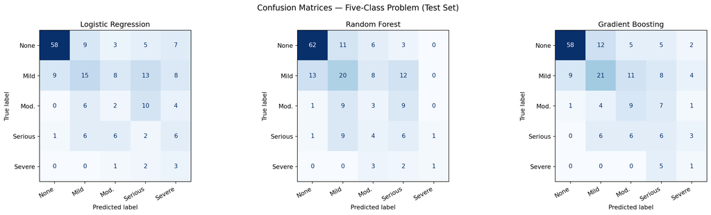

```python
fig, axes = plt.subplots(1, 3, figsize=(18, 5))
class_names_5 = ["None", "Mild", "Mod.", "Serious", "Severe"]

# Plot one confusion matrix per model side by side
for ax, preds, title in zip(
    axes,
    [y_pred_lr, y_pred_rf, y_pred_gb],
    ["Logistic Regression", "Random Forest", "Gradient Boosting"]
):
    cm   = confusion_matrix(y_test, preds)
    disp = ConfusionMatrixDisplay(cm, display_labels=class_names_5)
    disp.plot(ax=ax, colorbar=False, cmap="Blues")
    ax.set_title(title)
    ax.set_xticklabels(class_names_5, rotation=30, ha="right")

plt.suptitle("Confusion Matrices — Five-Class Problem (Test Set)", fontsize=13)
plt.tight_layout()
plt.show()
```

All three models concentrate correct predictions on the diagonal for class 0 (no disease) and show increasing confusion as severity rises.

### Confusion Matrices — Three-Class Models

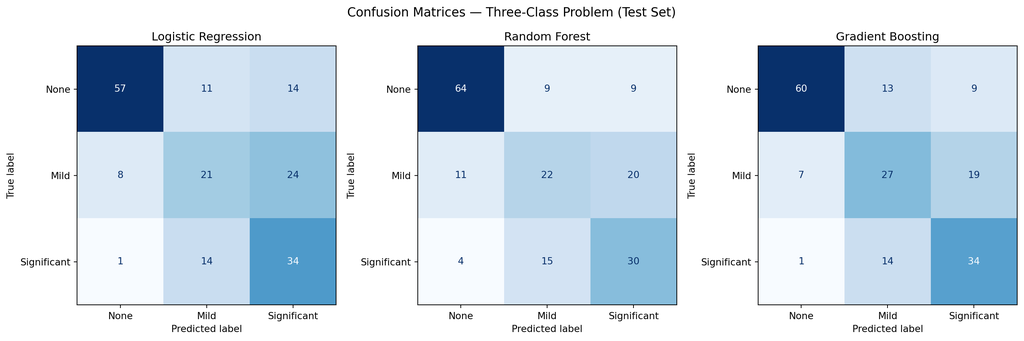

```python
fig, axes = plt.subplots(1, 3, figsize=(15, 5))
class_names_3 = ["None", "Mild", "Significant"]

for ax, preds, title in zip(
    axes,
    [y_pred_lr_c, y_pred_rf_c, y_pred_gb_c],
    ["Logistic Regression", "Random Forest", "Gradient Boosting"]
):
    cm   = confusion_matrix(y_test_c, preds)
    disp = ConfusionMatrixDisplay(cm, display_labels=class_names_3)
    disp.plot(ax=ax, colorbar=False, cmap="Blues")
    ax.set_title(title)

plt.suptitle("Confusion Matrices — Three-Class Problem (Test Set)", fontsize=13)
plt.tight_layout()
plt.show()
```

In the five-class matrices, the diagonal is dark only for “None”. Every other row is spread thinly and unevenly across five columns, meaning the models are essentially guessing among the disease severity levels. The moderate, serious, and severe rows in particular are nearly uniform in color, meaning predictions are no better than random for those classes.

### Feature Importance

The random forest provides a natural measure of feature importance: how much each feature reduces prediction error across all decision splits on average. Features at the top contributed the most information.

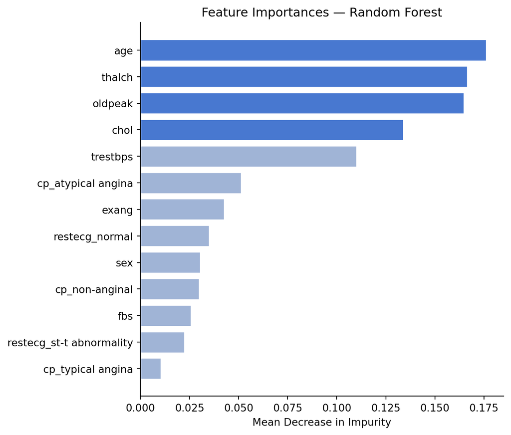

```python
# Extract the one-hot encoded feature names from the fitted preprocessor
# so the importance plot uses readable labels instead of column indices
ohe_features  = (rf_search.best_estimator_
                 .named_steps["preprocessor"]
                 .named_transformers_["cat"]
                 .get_feature_names_out(categorical_cols))
feature_names = numeric_cols + binary_cols + list(ohe_features)

# Build a named Series from the feature importances stored in the fitted forest
importances = pd.Series(
    rf_search.best_estimator_.named_steps["model"].feature_importances_,
    index=feature_names
).sort_values(ascending=True)

fig, ax = plt.subplots(figsize=(7, 6))

# Highlight the top quartile of features in a darker blue
colors = ["#4878d0" if v >= importances.quantile(0.75) else "#a0b4d6"
          for v in importances]
ax.barh(importances.index, importances.values, color=colors, edgecolor="white")
ax.set_xlabel("Mean Decrease in Impurity")
ax.set_title("Feature Importances — Random Forest")
sns.despine()
plt.tight_layout()
plt.show()
```

Maximum heart rate, ST depression, and age are consistently the top numeric predictors, which aligns exactly with the patterns observed in the EDA ( Exploratory Data Analysis) above. This agreement between EDA and model-derived importances gives us confidence that the model is learning real clinical signal rather than noise.

### Model Comparison Summary

```python
# Summarize all six model configurations (5-class and 3-class) in a single table
comparison = pd.DataFrame({
    "Model":              ["Logistic Regression", "Random Forest", "Gradient Boosting",
                           "Logistic Regression (3-class)", "Random Forest (3-class)", "Gradient Boosting (3-class)"],
    "CV Bal. Accuracy":   [round(lr_search.best_score_,   3),
                           round(rf_search.best_score_,   3),
                           round(gb_search.best_score_,   3),
                           round(lr_search_c.best_score_, 3),
                           round(rf_search_c.best_score_, 3),
                           round(gb_search_c.best_score_, 3)],
    "Test Bal. Accuracy": [round(bal_acc_lr, 3),
                           round(bal_acc_rf, 3),
                           round(bal_acc_gb, 3),
                           round(balanced_accuracy_score(y_test_c, y_pred_lr_c), 3),
                           round(balanced_accuracy_score(y_test_c, y_pred_rf_c), 3),
                           round(balanced_accuracy_score(y_test_c, y_pred_gb_c), 3)],
})
comparison
```

|  | Model | CV Bal. Accuracy | Test Bal. Accuracy |
| --- | --- | --- | --- |
| 0 | Logistic Regression | 0.382 | 0.335 |
| 1 | Random Forest | 0.362 | 0.344 |
| 2 | Gradient Boosting | 0.370 | 0.393 |
| 3 | Logistic Regression (3-class) | 0.612 | 0.595 |
| 4 | Random Forest (3-class) | 0.603 | 0.603 |
| 5 | Gradient Boosting (3-class) | 0.605 | 0.645 |

## Conclusion

This analysis set out to predict the severity of heart disease across five levels using ten clinical features. Three algorithms were evaluated, logistic regression, random forest, and gradient boosting, each tuned with grid search and cross-validation.